# Análise Multivariada II - Aula 1

2018-08-23

## Dados perdidos

Considere que $n$ é o número de casos; $p$ é o número de variáveis. O número de casos completos deve ser maior ou igual a $2p$ , além disso, só utilizaremos este pacote no caso de haver valores perdidos e a função só se aplica se o número mínimo de casos para um grupo de casos perdidos for maior do que 1 e corresponde ao argumento `del.lesscases = 1` (o default é 6); se o conjunto de dados não tiver mais do que 1 dado perdido para cada grupo de casos perdidos, a função retornará erro.

O teste de hipótese a ser realizado pela função TestMCARNormality do pacote MissMech é $H_0:$ As variância dos grupos são iguais (homocedasticidade)

Ativando pacotes necessários:

```r
if(!require(MissMech)){install.packages("MissMech", repos = "https://cran.revolutionanalytics.com")}
if(!require(DescTools)){install.packages("DescTools", repos = "https://cran.revolutionanalytics.com")}
if(!require(Amelia)){install.packages("Amelia", repos = "https://cran.revolutionanalytics.com")}

require(Amelia)
require(DescTools)
require(MissMech)
require(tidyverse)
```

```r
#Exemplo: vamos criar um conjunto de dados com 20 casos e 5 variáveis.
#MAR - dados perdidos ao acaso (Missin at Random)
#MCAR - dados perdidos completamente ao acaso (Missing Completaly at Random)

n <- 20
p <- 5

set.seed(1010)
y <- matrix(rnorm(n * p),nrow = n)

#Vamos definir alguns casos perdidos
y[1:4,3] <- NA
y[2:4,5] <- NA

#Visualizando os dados
y <- as.tibble(y)
y
```

```
# A tibble: 20 x 5
        V1      V2       V3       V4       V5
     <dbl>   <dbl>    <dbl>    <dbl>    <dbl>
 1  0.132   0.0849  NA       1.57      1.23
 2 -0.898   0.715   NA       0.645    NA
 3  1.35   -0.966   NA       0.853    NA
 4  0.420   0.462   NA      -0.360    NA
 5 -0.288  -0.686   -0.694   0.517     0.509
 6  1.36    0.739    0.157  -1.98     -1.36
 7  1.94   -0.319    0.326   0.563    -0.668
 8 -2.36   -1.05    -0.585  -0.437    -1.55
 9 -0.594  -0.286    0.337  -0.765     0.900
10 -0.545  -1.84     1.32   -0.00508  -2.63
11 -0.196  -1.04     1.83    0.546    -0.592
12 -0.830   1.92    -0.773  -0.314     0.673
13 -1.44   -0.147   -1.14   -0.752    -1.31
14 -0.0761  0.330   -0.372   1.05     -0.0477
15  0.726  -1.04     0.0239 -0.409    -1.14
16 -0.788   0.352   -0.179  -2.35     -0.528
17 -0.819  -0.275    0.930  -0.223    -1.08
18  0.205  -0.387    1.59   -0.145    -0.738
19 -0.952  -0.571   -0.119  -0.00796   1.17
20 -0.966  -0.991    1.62    2.12     -1.88
```

Visualizando dados faltantes:

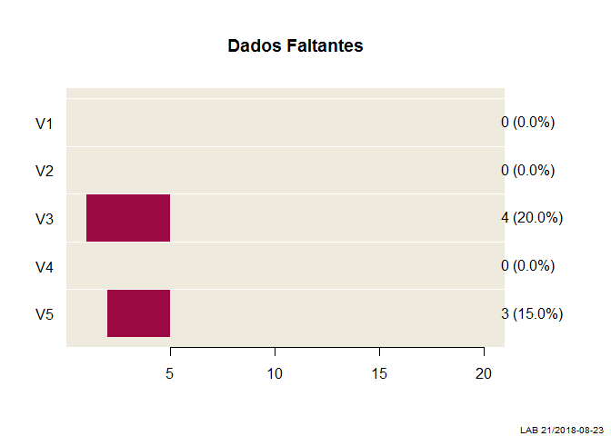

```r
PlotMiss(y, main="Dados Faltantes") # Do DescTools
```

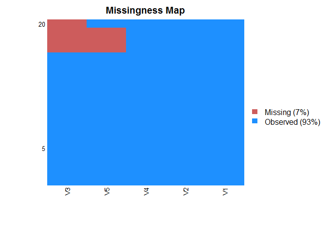

```r
# ou

missmap(y) # Amelia
```

Agora analisando com o pacote `MissMech`:

```r
out <- TestMCARNormality(data=y, del.lesscases = 1)
summary(out)
```

```
Number of imputation:  1

Number of Patterns:  2

Total number of cases used in the analysis:  19

 Pattern(s) used:
          V1   V2   V3   V4   V5   Number of cases
group.1    1    1   NA    1   NA                 3
group.2    1    1    1    1    1                16

    Test of normality and Homoscedasticity:
  -------------------------------------------

Hawkins Test:

    P-value for the Hawkins test of normality and homoscedasticity:  0.4359473

Non-Parametric Test:

    P-value for the non-parametric test of homoscedasticity:  0.584033
```

Observe que:

- Há um valor perdido no caso 1 (variável 3);
- Há 2 valores perdidos nos casos de 2 a 4 (variável 3 e variável 5) o que resultou em 2 grupos: grupo 1 com 3 casos e grupo 2 (caso completo) com 16 casos, totalizando 19 casos na análise;
- O caso 1 não é considerado pois há apenas um grupo com este padrão;

O teste retorna p-valor $0.44$ indicando a aceitação da normalidade multivariada e a aleatoriedade dos dados perdidos. Desse modo podemos realizar o processo de atribuição de valores aos casos perdidos.

1. Realize a análise para os dados da tabela 2.1 Ref. (Hair 6a.ed. pág 59)

```r
v1 <- c(1.3, 4.1, NA, 0.9, 0.4, 1.5, 0.2, 2.1, 1.8, 4.5, 2.5, 4.5, NA, 2.8, 3.7, 1.6, 0.5, 2.8, 2.2, 1.8)

v2 <- c(9.9, 5.7, 9.9, 8.6, 8.3, 6.7, 8.8, 8.0, 7.6, 8.0, 9.2, 6.4, NA, 6.1, NA, 6.4, 9.2, 5.2, 6.7, 9.0)

v3 <- c(6.7, rep(NA, 4), 4.8, 4.5, 3, rep(NA, 3), 5.3, NA, 6.4, NA, 5, NA, 5, NA, 5)

v4<- c(3.0, NA, 3.0, 2.1, 1.2,NA, 3.0, 3.8, 3.2, 3.3, 3.3, 3.0, NA , NA, 3.0, NA, 3.3, NA, 2.6, 2.2)

v5 <- c(2.6, 2.9, NA, 1.8, 1.7, 2.5, 2.4, 1.4, 2.5, 2.2, 3.9, 2.5, 2.7, 3.8, NA, 2.1, 2.8, 2.7, 2.9, 3)

dados <- tibble(v1, v2, v3, v4, v5)
```

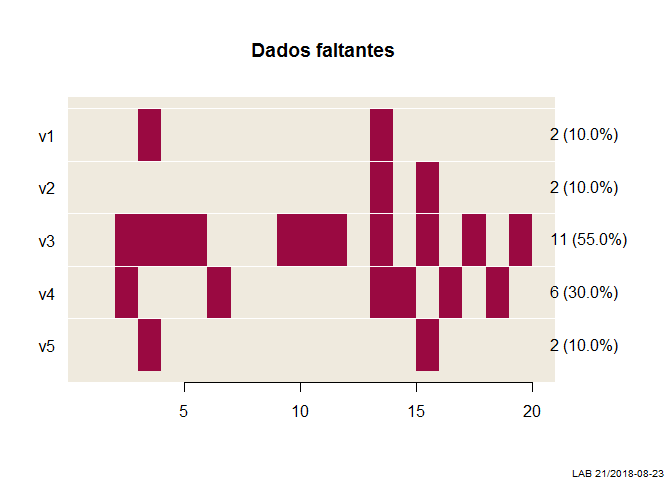

```r
PlotMiss(dados, main = "Dados faltantes")
```

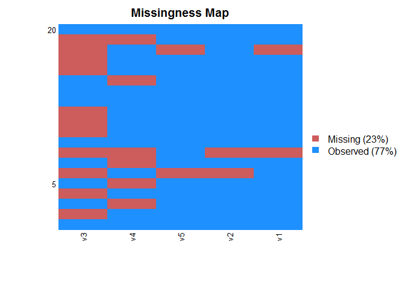

```r
missmap(dados)
```

```r
out <- TestMCARNormality(data = dados, del.lesscases = 1)
summary(out)
```

```
Number of imputation:  1

Number of Patterns:  3

Total number of cases used in the analysis:  16

 Pattern(s) used:
          v1   v2   v3   v4   v5   Number of cases
group.1    1    1    1    1    1                 5
group.2    1    1   NA    1    1                 7
group.3    1    1    1   NA    1                 4

    Test of normality and Homoscedasticity:
  -------------------------------------------

Hawkins Test:

    P-value for the Hawkins test of normality and homoscedasticity:  0.5196287

Non-Parametric Test:

    P-value for the non-parametric test of homoscedasticity:  0.108529
```